# Part II - (Insights Explanation On GoBike Data)

## by (Kitwana Shebabetsi execheil)

## Investigation Overview

In this investigation, I entend to understand the relationship between the starting day, hour and different gendersa and user type . I also want to understand what is in the ride duration compared to the type of user. Then i will eventually see the ride duration based on the whole member characteristics.

## Dataset Overview

My dataset contains the information about bike-sharing system from San Francisco Bay area. It is only for the year 2017, month of Frebruary. As the data scource constantly updates, what i found was on for february month.

## The relationship between Start riding day and the member gender

The `Male gender` has got more number of bike trips than `Female` and `Other`. With the `Other` gender having almost none ride. The largest bike trip was for Male gender and it is at 25000 On thursday. In all cases, no matter the gender, Tuesday to Thursday are the days of the week with plenty of rides than other day. Showing again, weekends with the least number of rides

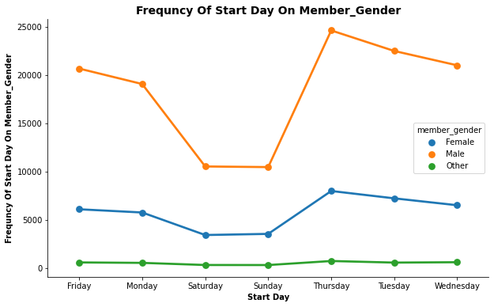

## The realationship between stard riding hour and User type

As we can see, the `Subscriber` and `Customer` have amost the same hour time from Midnight to 5 AM, at that time there is almost no ride. Then both Subscriber and customer raise up during the day time with Suscriber having more rides. Between **(8 AM and 9 AM)** and **(5 PM and 6 PM)** there are two peaks showing a lot of rides respectively. It explain the fact that it is the most active time for workers for the coming and going.

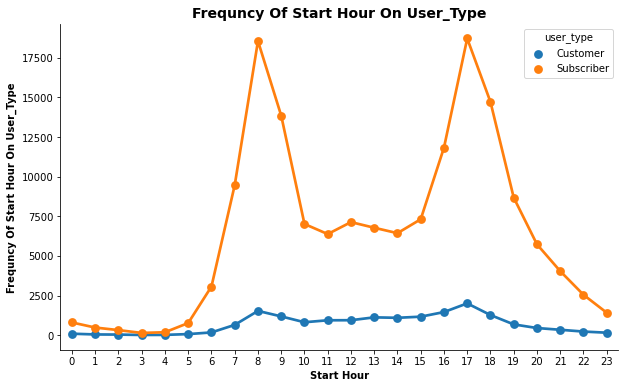

## The average duration for the day of the week based on the type of users

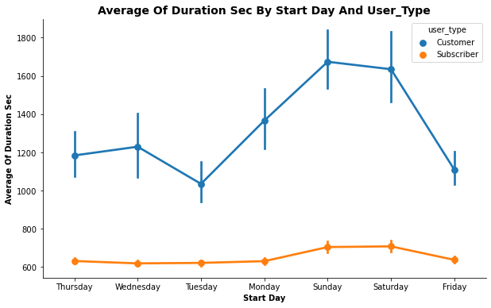

## Relationship between the member characterisitcs and Duration

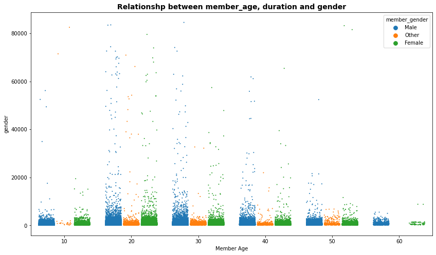